# The probabilistic implications of the high pre-1800 global child mortality and fertility rates

Before 1800, the global child mortality rate was [43%](https://ourworldindata.org/child-mortality) and global fertility rate (average number of children born per woman) was around [6](https://www.gapminder.org/topics/babies-per-woman/) [1,2]. One may wonder why women had so many children, far greater than the current global average of around 2.4 children born per woman. One possible reason is the lack of contraception, another is the potential usefulness of having many children to help out with subsistence farming, but there may be another reason.

Parents may have had many children to ensure that at least one or two successfully survive past childhood. With a high child mortality rate, only having two children runs a large risk that one or both might die before turning five years old. As discussed by [Haines](https://www.ncbi.nlm.nih.gov/books/NBK233807/), there is some historical evidence for this theory [3]. However, exploring the probabilties behind ensuring at least two children survive into adulthood may lend even greater support.

### References

[1] https://ourworldindata.org/child-mortality

[2] https://www.gapminder.org/topics/babies-per-woman/

[3] https://www.ncbi.nlm.nih.gov/books/NBK233807/

Here we can see the probability that a certain number of children will survive past 5 years old using the pre-1800 child mortality rate of 43% (before five years old) and fertility rate of 6 children per woman. You can see that it's most likely that about 3 or 4 children will survive past 5. It's highly unlikely that all six children will die (0.6%) and it's also highly unlikely that all six children will survive past five years old (3.4%).

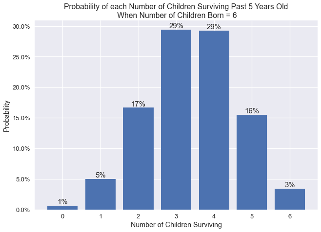

```python
import cmf
pre_1800_prob_6 = cmf.probabilities_num_alive(0.43, 6)
cmf.plot_probabilities_num_alive(pre_1800_prob_6)
```

We can plot all six histograms showing the probabilities of each number of children surviving when having 1 through 6 six children.

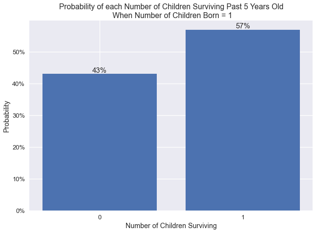

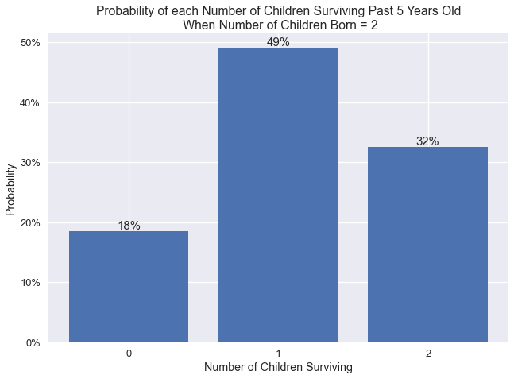

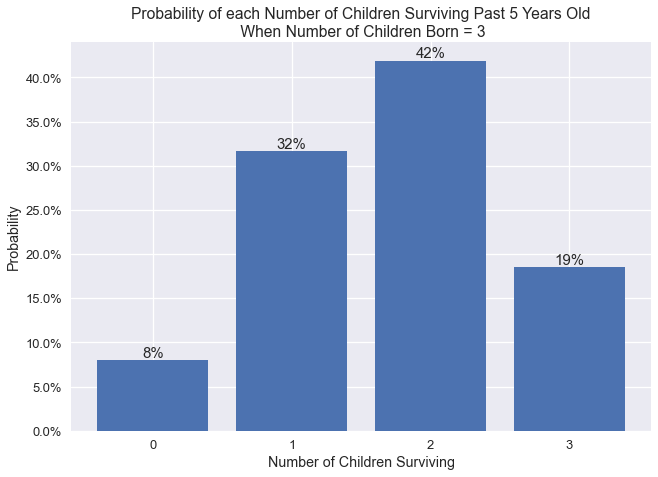

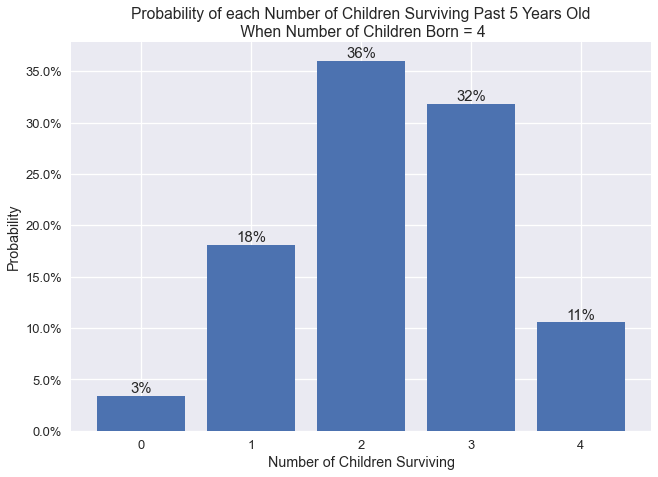

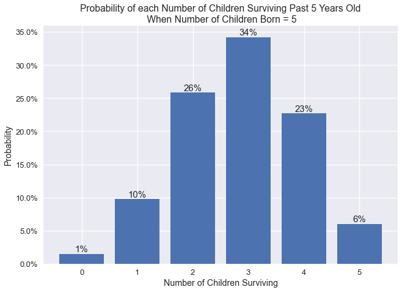

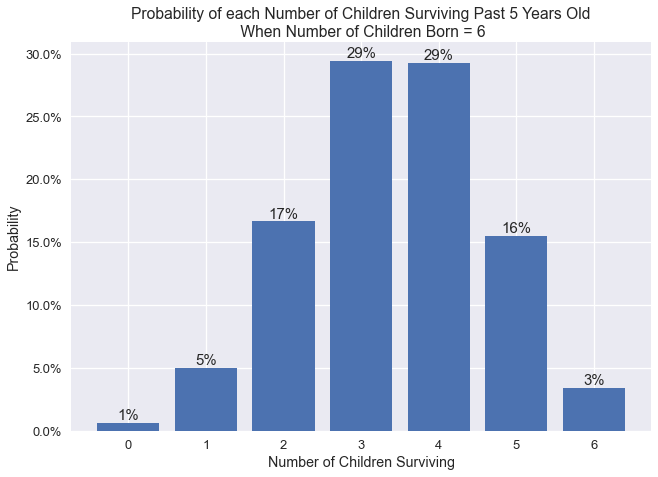

```python
pre_1800_1_to_6 = cmf.probabilities_num_alive_list(0.43, 6)
cmf.plot_probabilities_num_alive_list(pre_1800_1_to_6)
```

Here, we plot the expected number of children surviving based on number of children born. This increases linearly in increments of 0.57. That is, a pre-1800 couple having n children could expect n * 0.57 to survive past five years old. For example, a pre-1800 couple having 5 children could most likely expect 3 to survive and 2 to die before the age of five years old.

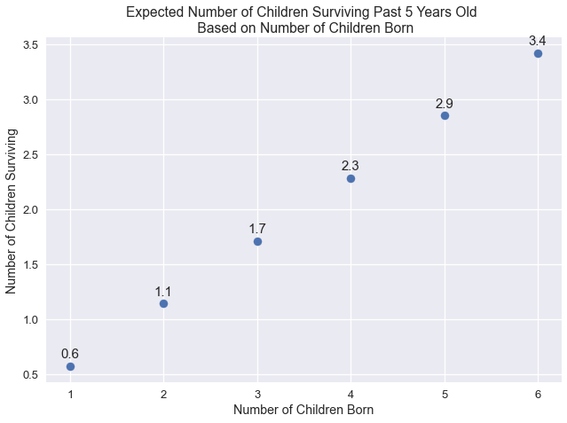

```python
pre_1800_ex_num_1_to_6 = cmf.expected_number_surviving_list(pre_1800_1_to_6)
cmf.plot_expected_number_surviving_list(pre_1800_ex_num_1_to_6)
```

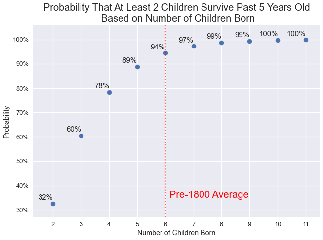

```python
cmf.plot_final()
```

There is diminishing marginal utility to having ever more children (in terms of obtaining the reproductive success of at least two children surviving past five). There are huge gains in the probability of reproductive success when going from 2 to 5 children, but past having 5 children, the gains become less and less, while the difficulty of raising the additional children likely remained relatively constant or possibly increased. At 6 children per woman, the value of increasing the probability of reproductive success from 94% to 97% may have been less than or equal to the cost of raising giving birth to or raising additional 7th child. Thus at that point, it may not have been rational to have the 7th child.

It's a somewhat speculative exercise to try to calculate the exact marginal cost versus marginal benefit of having an additional child, largely because we're not fully aware of how large the effects of the other factors affecting fertility rate were, as mentioned earlier. However, the goal of having one or two children survive into adulthood was likely a factor in driving the high fertility rate given the very high childhood mortality rate.